# A008_DadaPrep_Titanic_Kaggle

PoD Academy  
Formação Full Stack Data & Analytics

**Aula A008 - Data Preparation - Titanic**

Roberto Soares - LfLngLrnng

[in/roberto-soares-full-stack-data-journey](https://www.linkedin.com/in/roberto-soares-full-stack-data-scientist/)

[Portifólio: roberto-ssoares](https://github.com/roberto-ssoares/roberto-ssoares.github.io)

PoD Academy - Prof. Bruno Jardim  
[+] Faturamento,  
[-] Custo,  
[+] Qualidade de vida

**Neste notebook você vai aplicar o data prep básico nos dados do Titanic (Kaggle):**

- Conceito de Metadados
- Análise da Cardinalidade
- Normalizações
- Padronizações
- OneHot Encoding
- Label Encoding
- Salvar ABT tratada para próxima etapa

Instalando e Carregando Pacotes

Para atualizar um pacote, execute o comando abaixo no terminal ou prompt de comando:

- pip install -U nome_pacote

Para instalar a versão exata de um pacote, execute o comando abaixo no terminal ou prompt de comando:

- !pip install nome_pacote==versão_desejada

Depois de instalar ou atualizar o pacote, reinicie o jupyter notebook.

Instala o pacote watermark

- Esse pacote é usado para gravar as versões de outros pacotes usados neste jupyter notebook.

```python
#!pip install -q -U watermark
```

```python
import pandas as pd
import matplotlib.pyplot as plt
import missingno as msno

from sklearn.preprocessing import MinMaxScaler
from sklearn.preprocessing import OneHotEncoder
from sklearn.preprocessing import LabelEncoder
```

```python
# Versões dos pacotes usados neste jupyter notebook
%reload_ext watermark
%watermark -a "Roberto Soares - LfLngLrnng"
```

```
Author: Roberto Soares - LfLngLrnng
```

**Ler tabela para preparação de dados:**

```python
caminho = 'D:/_jupyter/pod/ds/mod06-ciencia-de-dados/data/'
titanic_csv = 'Titanic_Kaggle_Train.csv'
```

```python
# Ler diretório CSV
abt_00 = pd.read_csv(caminho+titanic_csv)
print(abt_00.shape)
```

```
(891, 12)
```

Lista de variaveis para retirar dos tratamentos

```python
# lista de vars para retirar dos tratamentos
lista_spec = ['PassengerId', 'Survived']

abt_01 = abt_00.drop(axis=1,columns = lista_spec)
abt_01.shape
```

```
(891, 10)
```

```python
abt_01.head()
```

|  | Pclass | Name | Sex | Age | SibSp | Parch | Ticket | Fare | Cabin | Embarked |
| --- | --- | --- | --- | --- | --- | --- | --- | --- | --- | --- |
| 0 | 3 | Braund, Mr. Owen Harris | male | 22.0 | 1 | 0 | A/5 21171 | 7.2500 | NaN | S |
| 1 | 1 | Cumings, Mrs. John Bradley (Florence Briggs Th... | female | 38.0 | 1 | 0 | PC 17599 | 71.2833 | C85 | C |
| 2 | 3 | Heikkinen, Miss. Laina | female | 26.0 | 0 | 0 | STON/O2. 3101282 | 7.9250 | NaN | S |
| 3 | 1 | Futrelle, Mrs. Jacques Heath (Lily May Peel) | female | 35.0 | 1 | 0 | 113803 | 53.1000 | C123 | S |
| 4 | 3 | Allen, Mr. William Henry | male | 35.0 | 0 | 0 | 373450 | 8.0500 | NaN | S |

```python
abt_01.tail()
```

|  | Pclass | Name | Sex | Age | SibSp | Parch | Ticket | Fare | Cabin | Embarked |
| --- | --- | --- | --- | --- | --- | --- | --- | --- | --- | --- |
| 886 | 2 | Montvila, Rev. Juozas | male | 27.0 | 0 | 0 | 211536 | 13.00 | NaN | S |
| 887 | 1 | Graham, Miss. Margaret Edith | female | 19.0 | 0 | 0 | 112053 | 30.00 | B42 | S |
| 888 | 3 | Johnston, Miss. Catherine Helen "Carrie" | female | NaN | 1 | 2 | W./C. 6607 | 23.45 | NaN | S |
| 889 | 1 | Behr, Mr. Karl Howell | male | 26.0 | 0 | 0 | 111369 | 30.00 | C148 | C |
| 890 | 3 | Dooley, Mr. Patrick | male | 32.0 | 0 | 0 | 370376 | 7.75 | NaN | Q |

Não é necessário aplicar feature engineering pois já o dataset já está na granularidade individuo e o problema trata do individuo, é possível combinar variáveis mas não agrupar variáveis.

**Agora precisamos aplicar data prep, temos que transformar as variáveis categóricas em números sem perder a informação.**

## Extrair títulos usando expressão regular

- Excluir a variável 'Name'

```python
# Extrair títulos usando expressão regular
abt_01['Titulo'] = abt_01['Name'].str.extract(' (Mr\.|Miss\.|Mrs\.|Dr\.) ')
abt_01.drop(axis=1,columns='Name',inplace=True)
abt_01.head()
```

|  | Pclass | Sex | Age | SibSp | Parch | Ticket | Fare | Cabin | Embarked | Titulo |
| --- | --- | --- | --- | --- | --- | --- | --- | --- | --- | --- |
| 0 | 3 | male | 22.0 | 1 | 0 | A/5 21171 | 7.2500 | NaN | S | Mr. |
| 1 | 1 | female | 38.0 | 1 | 0 | PC 17599 | 71.2833 | C85 | C | Mrs. |
| 2 | 3 | female | 26.0 | 0 | 0 | STON/O2. 3101282 | 7.9250 | NaN | S | Miss. |
| 3 | 1 | female | 35.0 | 1 | 0 | 113803 | 53.1000 | C123 | S | Mrs. |
| 4 | 3 | male | 35.0 | 0 | 0 | 373450 | 8.0500 | NaN | S | Mr. |

**Conceito de Metadados**

Função para gerar Dataframe de Metadados:

```python
def pod_academy_generate_metadata(dataframe):
    """
    Gera um dataframe contendo metadados das colunas do dataframe fornecido.

    :param dataframe: DataFrame para o qual os metadados serão gerados.
    :return: DataFrame contendo metadados.
    """

    # Coleta de metadados básicos
    metadata = pd.DataFrame({
        'nome_variavel': dataframe.columns,
        'tipo': dataframe.dtypes,
        'qt_nulos': dataframe.isnull().sum(),
        'percent_nulos': round((dataframe.isnull().sum() / len(dataframe))* 100,2),
        'cardinalidade': dataframe.nunique(),
    })
    metadata=metadata.sort_values(by='percent_nulos',ascending=False)
    metadata = metadata.reset_index(drop=True)

    return metadata
```

```python
metadata_df = pod_academy_generate_metadata(abt_01)
metadata_df.head(100)
```

|  | nome_variavel | tipo | qt_nulos | percent_nulos | cardinalidade |
| --- | --- | --- | --- | --- | --- |
| 0 | Cabin | object | 687 | 77.10 | 147 |
| 1 | Age | float64 | 177 | 19.87 | 88 |
| 2 | Titulo | object | 60 | 6.73 | 4 |
| 3 | Embarked | object | 2 | 0.22 | 3 |
| 4 | Pclass | int64 | 0 | 0.00 | 3 |
| 5 | Sex | object | 0 | 0.00 | 2 |
| 6 | SibSp | int64 | 0 | 0.00 | 7 |
| 7 | Parch | int64 | 0 | 0.00 | 7 |
| 8 | Ticket | object | 0 | 0.00 | 681 |
| 9 | Fare | float64 | 0 | 0.00 | 248 |

**A Biblioteca Missingno**

- Missingno é uma biblioteca Python excelente e simples de usar que fornece uma série de visualizações para entender a presença e distribuição de dados ausentes em um dataframe do pandas.
- Isso pode ser na forma de gráfico de barras, gráfico de matriz, mapa de calor ou dendograma.

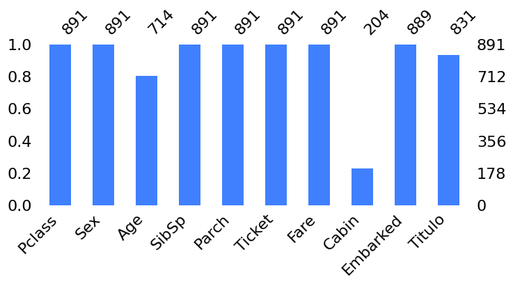

```python
msno.bar(abt_01, color=(0.25, 0.5, 1), figsize=(8, 3))  # tom de azul claro
```

Aplicando cutoff em variáveis com valores nulos

```python
# Variáveis numéricas
# Filtrando o DataFrame
missing_cutoff = 70
df_numericas_drop_nulos = metadata_df[(metadata_df['percent_nulos'] >= missing_cutoff)]
lista_drop_nulos_numericas = list(df_numericas_drop_nulos.nome_variavel.values)
lista_drop_nulos_numericas
```

```
['Cabin']
```

Retirando lista de variáveis com alto percentual de nulos

```python
# retirando lista de variáveis com alto percentual de nulos
abt_02 = abt_01.drop(axis=1,columns=lista_drop_nulos_numericas)
abt_02.shape
```

```
(891, 9)
```

Substituindo nulos pela média da variável numérica

```python
# substituindo nulos pela média da variável numérica
abt_02 = abt_02.fillna(abt_02.select_dtypes(include=['float64', 'int64','int32']).mean())
abt_02.shape
```

```
(891, 9)
```

Substituindo nulos por "Desconhecido" para categóricas

```python
# substituindo nulos por "Desconhecido" para categóricas
categorical_cols = abt_02.select_dtypes(include=['object']).columns
abt_02[categorical_cols] = abt_02[categorical_cols].fillna('Desconhecido')
abt_02.shape
```

```
(891, 9)
```

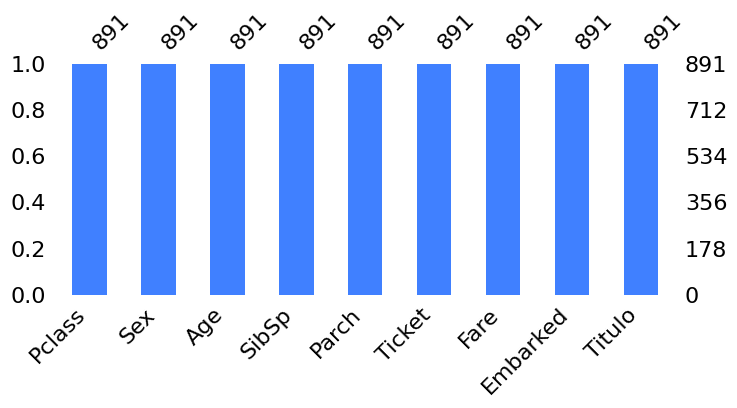

```python
msno.bar(abt_02, color=(0.25, 0.5, 1), figsize=(8, 3))  # tom de azul claro
```

**Normalizações / Padronizações**

**MinMaxScaler()**

- Transforme recursos dimensionando cada recurso para um determinado intervalo.
- Este estimador dimensiona e traduz cada recurso individualmente, de modo que fique no intervalo determinado no conjunto de treinamento, por exemplo, entre zero e um.
- Essa transformação é frequentemente usada como uma alternativa à escala de média zero e variância unitária.
- MinMaxScaler não reduz o efeito dos valores discrepantes, mas os reduz linearmente em um intervalo fixo, onde o maior ponto de dados que ocorre corresponde ao valor máximo e o menor corresponde ao valor mínimo.

```python
# Instanciando o scaler
scaler = MinMaxScaler()

# Selecionando colunas numéricas
numeric_cols = abt_02.select_dtypes(include=['float64', 'int64','int32']).columns

# Aplicando a normalização
abt_02[numeric_cols] = scaler.fit_transform(abt_02[numeric_cols])
abt_02.shape
```

```
(891, 9)
```

```python
abt_02.head()
```

|  | Pclass | Sex | Age | SibSp | Parch | Ticket | Fare | Embarked | Titulo |
| --- | --- | --- | --- | --- | --- | --- | --- | --- | --- |
| 0 | 1.0 | male | 0.271174 | 0.125 | 0.0 | A/5 21171 | 0.014151 | S | Mr. |
| 1 | 0.0 | female | 0.472229 | 0.125 | 0.0 | PC 17599 | 0.139136 | C | Mrs. |
| 2 | 1.0 | female | 0.321438 | 0.000 | 0.0 | STON/O2. 3101282 | 0.015469 | S | Miss. |
| 3 | 0.0 | female | 0.434531 | 0.125 | 0.0 | 113803 | 0.103644 | S | Mrs. |
| 4 | 1.0 | male | 0.434531 | 0.000 | 0.0 | 373450 | 0.015713 | S | Mr. |

**OneHot Encoding / Label Encoding**

**OneHotEncoder()**

```python
card_cutoff = 2
df_categ_onehot = metadata_df[(metadata_df['cardinalidade'] <= card_cutoff) & (metadata_df['tipo'] == 'object')]
lista_onehot = list(df_categ_onehot.nome_variavel.values)
print('Lista de vars para OneHot Encoding: ',lista_onehot)

# Instanciando o encoder
encoder = OneHotEncoder(drop='first', sparse_output=False)

# Aplicando o one-hot encoding
encoded_data = encoder.fit_transform(abt_02[lista_onehot])

# Criando um DataFrame com as colunas codificadas, mantendo o índice original
encoded_cols = encoder.get_feature_names_out(lista_onehot)
encoded_df = pd.DataFrame(encoded_data, columns=encoded_cols, index=abt_02.index)

# Concatenando o DataFrame codificado com o DataFrame original
abt_02 = pd.concat([abt_02.drop(lista_onehot, axis=1), encoded_df], axis=1)

abt_02.head()
```

```
Lista de vars para OneHot Encoding:  ['Sex']
```

|  | Pclass | Age | SibSp | Parch | Ticket | Fare | Embarked | Titulo | Sex_male |
| --- | --- | --- | --- | --- | --- | --- | --- | --- | --- |
| 0 | 1.0 | 0.271174 | 0.125 | 0.0 | A/5 21171 | 0.014151 | S | Mr. | 1.0 |
| 1 | 0.0 | 0.472229 | 0.125 | 0.0 | PC 17599 | 0.139136 | C | Mrs. | 0.0 |
| 2 | 1.0 | 0.321438 | 0.000 | 0.0 | STON/O2. 3101282 | 0.015469 | S | Miss. | 0.0 |
| 3 | 0.0 | 0.434531 | 0.125 | 0.0 | 113803 | 0.103644 | S | Mrs. | 0.0 |
| 4 | 1.0 | 0.434531 | 0.000 | 0.0 | 373450 | 0.015713 | S | Mr. | 1.0 |

**LabelEncoder()**

- LabelEncoder é uma classe da biblioteca scikit-learn usada para codificar dados categóricos (não numéricos) em rótulos numéricos.
- Esta é uma etapa comum de pré-processamento no aprendizado de máquina, pois muitos algoritmos exigem que os dados de entrada estejam em formato numérico.X.

```python
df_categ_labelenc = metadata_df[(metadata_df['cardinalidade'] > card_cutoff) & (metadata_df['tipo'] == 'object')]
lista_vars_abt = list(abt_02.columns)
lista_lenc = list(df_categ_labelenc.nome_variavel.values)

for item in lista_drop_nulos_numericas:
    if item in lista_lenc:
        lista_lenc.remove(item)

print('Lista de vars para Label Encoding: ',lista_lenc)
```

```
Lista de vars para Label Encoding:  ['Titulo', 'Embarked', 'Ticket']
```

```python
# Aplicando LabelEncoder nas colunas desejadas
for col in lista_lenc:
    encoder = LabelEncoder()
    abt_02[col] = encoder.fit_transform(abt_02[col])

abt_02.head()
```

|  | Pclass | Age | SibSp | Parch | Ticket | Fare | Embarked | Titulo | Sex_male |
| --- | --- | --- | --- | --- | --- | --- | --- | --- | --- |
| 0 | 1.0 | 0.271174 | 0.125 | 0.0 | 523 | 0.014151 | 3 | 3 | 1.0 |
| 1 | 0.0 | 0.472229 | 0.125 | 0.0 | 596 | 0.139136 | 0 | 4 | 0.0 |
| 2 | 1.0 | 0.321438 | 0.000 | 0.0 | 669 | 0.015469 | 3 | 2 | 0.0 |
| 3 | 0.0 | 0.434531 | 0.125 | 0.0 | 49 | 0.103644 | 3 | 4 | 0.0 |
| 4 | 1.0 | 0.434531 | 0.000 | 0.0 | 472 | 0.015713 | 3 | 3 | 1.0 |

```python
# Inner join usando o índice
abt_model = pd.merge(abt_02, abt_00[['Survived']], left_index=True, right_index=True, how='inner')
abt_model.shape
```

```
(891, 10)
```

```python
abt_model.head()
```

|  | Pclass | Age | SibSp | Parch | Ticket | Fare | Embarked | Titulo | Sex_male | Survived |
| --- | --- | --- | --- | --- | --- | --- | --- | --- | --- | --- |
| 0 | 1.0 | 0.271174 | 0.125 | 0.0 | 523 | 0.014151 | 3 | 3 | 1.0 | 0 |
| 1 | 0.0 | 0.472229 | 0.125 | 0.0 | 596 | 0.139136 | 0 | 4 | 0.0 | 1 |
| 2 | 1.0 | 0.321438 | 0.000 | 0.0 | 669 | 0.015469 | 3 | 2 | 0.0 | 1 |
| 3 | 0.0 | 0.434531 | 0.125 | 0.0 | 49 | 0.103644 | 3 | 4 | 0.0 | 1 |
| 4 | 1.0 | 0.434531 | 0.000 | 0.0 | 472 | 0.015713 | 3 | 3 | 1.0 | 0 |

```python
abt_model.to_csv(caminho+'abt_titanic.csv')
```

```python
abt_00.head()
```

|  | PassengerId | Survived | Pclass | Name | Sex | Age | SibSp | Parch | Ticket | Fare | Cabin | Embarked |
| --- | --- | --- | --- | --- | --- | --- | --- | --- | --- | --- | --- | --- |
| 0 | 1 | 0 | 3 | Braund, Mr. Owen Harris | male | 22.0 | 1 | 0 | A/5 21171 | 7.2500 | NaN | S |
| 1 | 2 | 1 | 1 | Cumings, Mrs. John Bradley (Florence Briggs Th... | female | 38.0 | 1 | 0 | PC 17599 | 71.2833 | C85 | C |
| 2 | 3 | 1 | 3 | Heikkinen, Miss. Laina | female | 26.0 | 0 | 0 | STON/O2. 3101282 | 7.9250 | NaN | S |
| 3 | 4 | 1 | 1 | Futrelle, Mrs. Jacques Heath (Lily May Peel) | female | 35.0 | 1 | 0 | 113803 | 53.1000 | C123 | S |
| 4 | 5 | 0 | 3 | Allen, Mr. William Henry | male | 35.0 | 0 | 0 | 373450 | 8.0500 | NaN | S |

```python
%reload_ext watermark
%watermark -a "Roberto Soares - LfLngLrnng"
```

```
Author: Roberto Soares - LfLngLrnng
```

```python
%watermark -v -m
```

```
Python implementation: CPython
Python version       : 3.11.0
IPython version      : 8.25.0

Compiler    : MSC v.1929 64 bit (AMD64)
OS          : Windows
Release     : 10
Machine     : AMD64
Processor   : Intel64 Family 6 Model 158 Stepping 9, GenuineIntel
CPU cores   : 4
Architecture: 64bit
```

```python
%watermark --iversions
```

```
matplotlib: 3.8.4
pandas    : 2.2.2
missingno : 0.5.2
```

**Fim**

```python
%%capture
!!jupyter nbconvert --to html A008_DadaPrep_Titanic_Kaggle.ipynb
```